# Introduction to Rstudio, and seeing what R can do

## 1. RStudio

Open RStudio.

#### RStudio panes

The RStudio interface consists of four main panes, or windows.

- **Bottom left**: console or command window. Here you can type any valid R command after the > prompt followed by Enter and R will execute that command.
- **Top left**: text editor or script window. This is where you can save and edit collections of commands.
- **Top right**: environment & history window. The environment window contains objects (data, values, functions) R has currently stored in its memory. The history window shows all commands that were executed in the console.
- **Bottom right**: files, plots, packages, help, & viewer pane. Here you can open files, view plots, install and load packages, read man pages, and view markdown and other documents in the viewer tab.

The location of these windows can be changed by clicking Tools > Global Options > Pane Layout.

You may have noticed that, by default, there is no text editor window open. In order to open one, click File > New File > R Script. Alternatively, click the 'Add new document' symbol and select R Script.

Open a new R script in R and **save it as** `wpa_1_LastFirst.R` (where Last and First is your last and first name).

Careful about capitalizing, and using `_` and **not**, e.g., `WPA-1-LastFirst.R`

At the top of your script, write the following (**with appropriate changes**):

```r
# Assignment: WPA 1
# Name: Laura Fontanesi
# Date: 2 March 2021
```

#### Code completion

RStudio supports automatic completion of code using the **Tab key**.

For example, let's create a new object, named `my_block_rewards`:

```r
my_block_rewards = c(34, 36, 90)
```

Now, you can type `my` and then press Tab and RStudio will automatically complete the full name of the object if `my` is unique; otherwise, RStudio will list all of the objects (or functions) starting with `my` in your current environment.

Try now to define another object starting with `my` and see what happens.

```r
my_score = .4
```

Code completion also works for function arguments.

`data()` is a function to load one of R preset dataframes.

Type `data(m` in the console, then hit Tab to bring up a list of options. RStudio will automatically add a closing parenthesis for you, but your cursor needs to be between the two parentheses for tab completion to work.

Choose `mtcars` from the list and press Enter. What happens?

#### Environment browser

The `mtcars` object should have appeared in your environment tab.

The environment tab is in the top right window, which displays the R objects that exist in the global environment. These are the objects that were created by you in your current session.

If you click the load symbol next to the `mtcars` object, you can see the structure of the object. You can also click the view icon load to have a table view of the dataset. This might come useful at times.

#### Run some code in your script file

What we want to do most of time is to run our code from the script and not from the console. This will help us writing more complicated functions and keep track of exactly what we have been doing up to that point.

You always have the choice to run part of it or the whole code. I suggest (particularly at the begginning) to always run from the start to the end of your code, and to make sure that your workspace is clean at the beginning.

It's very useful to use shortcuts for this, for example:

| Description | Windows & Linux | Mac |
| --- | --- | --- |
| Run current line/selection | Ctrl+Enter | Command+Enter |
| Run current line/selection (retain cursor position) | Alt+Enter | Option+Enter |
| Run current document | Ctrl+Alt+R | Command+Option+R |
| Run from document beginning to current line | Ctrl+Alt+B | Command+Option+B |
| Run from current line to document end | Ctrl+Alt+E | Command+Option+E |

See [here](https://support.rstudio.com/hc/en-us/articles/200711853-Keyboard-Shortcuts) for more.

Practice with the following chunk of code:

```r
data(mtcars)

head(mtcars)

colnames(mtcars)

colnames(mtcars)[1] = 'MPG'

head(mtcars)
```

A data.frame: 6 × 11

|  | mpg <dbl> | cyl <dbl> | disp <dbl> | hp <dbl> | drat <dbl> | wt <dbl> | qsec <dbl> | vs <dbl> | am <dbl> | gear <dbl> | carb <dbl> |
| --- | --- | --- | --- | --- | --- | --- | --- | --- | --- | --- | --- |
| Mazda RX4 | 21.0 | 6 | 160 | 110 | 3.90 | 2.620 | 16.46 | 0 | 1 | 4 | 4 |
| Mazda RX4 Wag | 21.0 | 6 | 160 | 110 | 3.90 | 2.875 | 17.02 | 0 | 1 | 4 | 4 |
| Datsun 710 | 22.8 | 4 | 108 | 93 | 3.85 | 2.320 | 18.61 | 1 | 1 | 4 | 1 |
| Hornet 4 Drive | 21.4 | 6 | 258 | 110 | 3.08 | 3.215 | 19.44 | 1 | 0 | 3 | 1 |
| Hornet Sportabout | 18.7 | 8 | 360 | 175 | 3.15 | 3.440 | 17.02 | 0 | 0 | 3 | 2 |
| Valiant | 18.1 | 6 | 225 | 105 | 2.76 | 3.460 | 20.22 | 1 | 0 | 3 | 1 |

1. 'mpg'

2. 'cyl'

3. 'disp'

4. 'hp'

5. 'drat'

6. 'wt'

7. 'qsec'

8. 'vs'

9. 'am'

10. 'gear'

11. 'carb'

A data.frame: 6 × 11

|  | MPG <dbl> | cyl <dbl> | disp <dbl> | hp <dbl> | drat <dbl> | wt <dbl> | qsec <dbl> | vs <dbl> | am <dbl> | gear <dbl> | carb <dbl> |
| --- | --- | --- | --- | --- | --- | --- | --- | --- | --- | --- | --- |
| Mazda RX4 | 21.0 | 6 | 160 | 110 | 3.90 | 2.620 | 16.46 | 0 | 1 | 4 | 4 |
| Mazda RX4 Wag | 21.0 | 6 | 160 | 110 | 3.90 | 2.875 | 17.02 | 0 | 1 | 4 | 4 |
| Datsun 710 | 22.8 | 4 | 108 | 93 | 3.85 | 2.320 | 18.61 | 1 | 1 | 4 | 1 |
| Hornet 4 Drive | 21.4 | 6 | 258 | 110 | 3.08 | 3.215 | 19.44 | 1 | 0 | 3 | 1 |
| Hornet Sportabout | 18.7 | 8 | 360 | 175 | 3.15 | 3.440 | 17.02 | 0 | 0 | 3 | 2 |
| Valiant | 18.1 | 6 | 225 | 105 | 2.76 | 3.460 | 20.22 | 1 | 0 | 3 | 1 |

#### Retrieving previous commands

It's often the case that you want to re-execute commands that you previously entered. The RStudio console supports the ability to recall previous commands using the arrow keys:

- Up — Recall previous command(s)
- Down — Reverse of Up

You can even view a list of your recent commands by pressing Ctrl+Up on Windows or Command+Up on a Mac.

See [here](https://twitter.com/rstudiotips) for more RStudio tips.

## 2. Install packages

```r
install.packages('tidyverse')
```

```r
library('tidyverse')
```

## 3. Load and inspect some data

```r
# load data without downloading

con = url('https://github.com/laurafontanesi/r-seminar/blob/main/data/movies.RData?raw=true')
load(con)
close(con)
```

```r
# command to list all the variables in your workspace
ls()
```

1. 'con'

2. 'cormat'

3. 'movies'

4. 'mtcars'

5. 'my_block_rewards'

6. 'my_score'

7. 'regression_fit'

```r
# inspect the first 5 lines of a dataset

movies %>%
  slice(1:5)
```

A tibble: 5 × 32

| title <chr> | title_type <fct> | genre <fct> | runtime <dbl> | mpaa_rating <fct> | studio <fct> | thtr_rel_year <dbl> | thtr_rel_month <dbl> | thtr_rel_day <dbl> | dvd_rel_year <dbl> | ⋯ | best_dir_win <fct> | top200_box <fct> | director <chr> | actor1 <chr> | actor2 <chr> | actor3 <chr> | actor4 <chr> | actor5 <chr> | imdb_url <chr> | rt_url <chr> |
| --- | --- | --- | --- | --- | --- | --- | --- | --- | --- | --- | --- | --- | --- | --- | --- | --- | --- | --- | --- | --- |
| Filly Brown | Feature Film | Drama | 80 | R | Indomina Media Inc. | 2013 | 4 | 19 | 2013 | ⋯ | no | no | Michael D. Olmos | Gina Rodriguez | Jenni Rivera | Lou Diamond Phillips | Emilio Rivera | Joseph Julian Soria | http://www.imdb.com/title/tt1869425/ | //www.rottentomatoes.com/m/filly_brown_2012/ |
| The Dish | Feature Film | Drama | 101 | PG-13 | Warner Bros. Pictures | 2001 | 3 | 14 | 2001 | ⋯ | no | no | Rob Sitch | Sam Neill | Kevin Harrington | Patrick Warburton | Tom Long | Genevieve Mooy | http://www.imdb.com/title/tt0205873/ | //www.rottentomatoes.com/m/dish/ |
| Waiting for Guffman | Feature Film | Comedy | 84 | R | Sony Pictures Classics | 1996 | 8 | 21 | 2001 | ⋯ | no | no | Christopher Guest | Christopher Guest | Catherine O'Hara | Parker Posey | Eugene Levy | Bob Balaban | http://www.imdb.com/title/tt0118111/ | //www.rottentomatoes.com/m/waiting_for_guffman/ |
| The Age of Innocence | Feature Film | Drama | 139 | PG | Columbia Pictures | 1993 | 10 | 1 | 2001 | ⋯ | yes | no | Martin Scorsese | Daniel Day-Lewis | Michelle Pfeiffer | Winona Ryder | Richard E. Grant | Alec McCowen | http://www.imdb.com/title/tt0106226/ | //www.rottentomatoes.com/m/age_of_innocence/ |
| Malevolence | Feature Film | Horror | 90 | R | Anchor Bay Entertainment | 2004 | 9 | 10 | 2005 | ⋯ | no | no | Stevan Mena | Samantha Dark | R. Brandon Johnson | Brandon Johnson | Heather Magee | Richard Glover | http://www.imdb.com/title/tt0388230/ | //www.rottentomatoes.com/m/10004684-malevolence/ |

```r
summary(movies)
```

```
    title                  title_type                 genre        runtime
 Length:651         Documentary : 55   Drama             :305   Min.   : 39.0
 Class :character   Feature Film:591   Comedy            : 87   1st Qu.: 92.0
 Mode  :character   TV Movie    :  5   Action & Adventure: 65   Median :103.0
                                       Mystery & Suspense: 59   Mean   :105.8
                                       Documentary       : 52   3rd Qu.:115.8
                                       Horror            : 23   Max.   :267.0
                                       (Other)           : 60   NA's   :1
  mpaa_rating                               studio    thtr_rel_year
 G      : 19   Paramount Pictures              : 37   Min.   :1970
 NC-17  :  2   Warner Bros. Pictures           : 30   1st Qu.:1990
 PG     :118   Sony Pictures Home Entertainment: 27   Median :2000
 PG-13  :133   Universal Pictures              : 23   Mean   :1998
 R      :329   Warner Home Video               : 19   3rd Qu.:2007
 Unrated: 50   (Other)                         :507   Max.   :2014
               NA's                            :  8
 thtr_rel_month   thtr_rel_day    dvd_rel_year  dvd_rel_month
 Min.   : 1.00   Min.   : 1.00   Min.   :1991   Min.   : 1.000
 1st Qu.: 4.00   1st Qu.: 7.00   1st Qu.:2001   1st Qu.: 3.000
 Median : 7.00   Median :15.00   Median :2004   Median : 6.000
 Mean   : 6.74   Mean   :14.42   Mean   :2004   Mean   : 6.333
 3rd Qu.:10.00   3rd Qu.:21.00   3rd Qu.:2008   3rd Qu.: 9.000
 Max.   :12.00   Max.   :31.00   Max.   :2015   Max.   :12.000
                                 NA's   :8      NA's   :8
  dvd_rel_day     imdb_rating    imdb_num_votes           critics_rating
 Min.   : 1.00   Min.   :1.900   Min.   :   180   Certified Fresh:135
 1st Qu.: 7.00   1st Qu.:5.900   1st Qu.:  4546   Fresh          :209
 Median :15.00   Median :6.600   Median : 15116   Rotten         :307
 Mean   :15.01   Mean   :6.493   Mean   : 57533
 3rd Qu.:23.00   3rd Qu.:7.300   3rd Qu.: 58300
 Max.   :31.00   Max.   :9.000   Max.   :893008
 NA's   :8
 critics_score    audience_rating audience_score  best_pic_nom best_pic_win
 Min.   :  1.00   Spilled:275     Min.   :11.00   no :629      no :644
 1st Qu.: 33.00   Upright:376     1st Qu.:46.00   yes: 22      yes:  7
 Median : 61.00                   Median :65.00
 Mean   : 57.69                   Mean   :62.36
 3rd Qu.: 83.00                   3rd Qu.:80.00
 Max.   :100.00                   Max.   :97.00

 best_actor_win best_actress_win best_dir_win top200_box   director
 no :558        no :579          no :608      no :636    Length:651
 yes: 93        yes: 72          yes: 43      yes: 15    Class :character
                                                         Mode  :character




    actor1             actor2             actor3             actor4
 Length:651         Length:651         Length:651         Length:651
 Class :character   Class :character   Class :character   Class :character
 Mode  :character   Mode  :character   Mode  :character   Mode  :character




    actor5            imdb_url            rt_url
 Length:651         Length:651         Length:651
 Class :character   Class :character   Class :character
 Mode  :character   Mode  :character   Mode  :character
```

#### Continuous variables

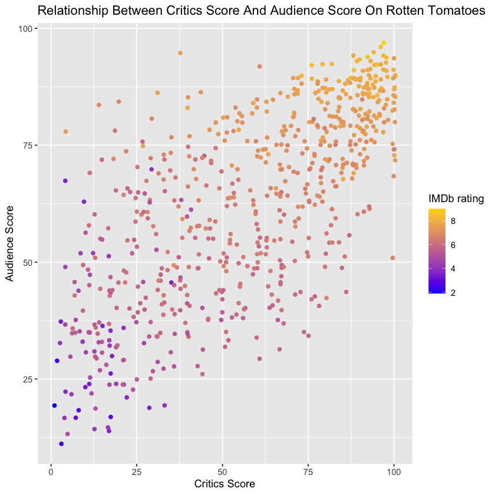

```r
# plot relationship between two variables, critics_score and audience_score

ggplot(data = movies, aes(x = critics_score, y = audience_score, color=imdb_rating)) +
  geom_jitter() +
  scale_colour_gradient(low = "blue", high = "gold", limits=range(movies[,'imdb_rating'])) +
  labs(x = "Critics Score", y = "Audience Score", color='IMDb rating') +
  ggtitle("Relationship Between Critics Score And Audience Score On Rotten Tomatoes")
```

```r
# Run a correlation test
cor.test(~ audience_score + critics_score, data = movies)
```

```
	Pearson's product-moment correlation

data:  audience_score and critics_score
t = 25.273, df = 649, p-value < 2.2e-16
alternative hypothesis: true correlation is not equal to 0
95 percent confidence interval:
 0.6633319 0.7410163
sample estimates:
      cor
0.7042762
```

```r
# Run a regression
regression_fit = lm(formula = audience_score ~ critics_score + imdb_rating,
                    data = movies)

# Print summary results
summary(regression_fit)
```

```
Call:
lm(formula = audience_score ~ critics_score + imdb_rating, data = movies)

Residuals:
    Min      1Q  Median      3Q     Max
-26.668  -6.758   0.723   5.513  52.438

Coefficients:
               Estimate Std. Error t value Pr(>|t|)
(Intercept)   -37.03195    2.86401 -12.930  < 2e-16 ***
critics_score   0.07318    0.02161   3.386 0.000753 ***
imdb_rating    14.65760    0.56590  25.901  < 2e-16 ***
---
Signif. codes:  0 ‘***’ 0.001 ‘**’ 0.01 ‘*’ 0.05 ‘.’ 0.1 ‘ ’ 1

Residual standard error: 10.08 on 648 degrees of freedom
Multiple R-squared:  0.7524,	Adjusted R-squared:  0.7516
F-statistic: 984.4 on 2 and 648 DF,  p-value: < 2.2e-16
```

```r
cormat = cor(movies[, c('audience_score', 'critics_score', 'imdb_rating', 'imdb_num_votes')])
cormat
```

A matrix: 4 × 4 of type dbl

|  | audience_score | critics_score | imdb_rating | imdb_num_votes |
| --- | --- | --- | --- | --- |
| audience_score | 1.0000000 | 0.7042762 | 0.8648652 | 0.2898128 |
| critics_score | 0.7042762 | 1.0000000 | 0.7650355 | 0.2092508 |
| imdb_rating | 0.8648652 | 0.7650355 | 1.0000000 | 0.3311525 |
| imdb_num_votes | 0.2898128 | 0.2092508 | 0.3311525 | 1.0000000 |

#### Discrete variables

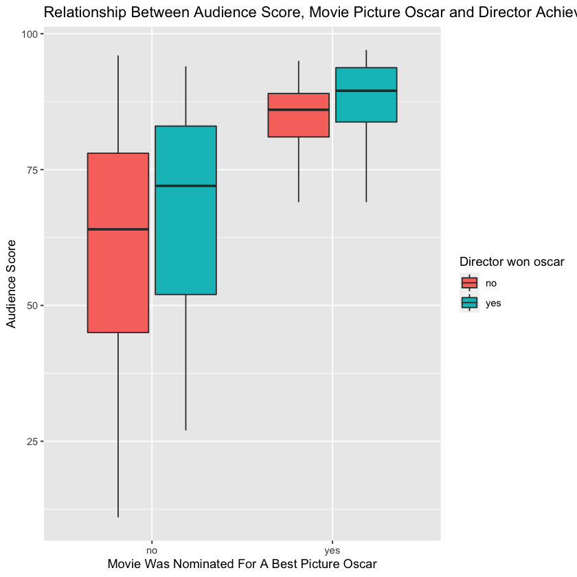

```r
ggplot(data = movies, aes(x = best_pic_nom, y = audience_score, fill = best_dir_win)) +
  geom_boxplot() +
  labs(x = "Movie Was Nominated For A Best Picture Oscar", y = "Audience Score", fill = "Director won oscar") +
  ggtitle("Relationship Between Audience Score, Movie Picture Oscar and Director Achievement")
```

```r
# Run an ANOVA
anova_fit = aov(formula = audience_score ~ best_pic_nom * best_dir_win,
                data = movies)

# Print summary results
summary(anova_fit)
```

```
                           Df Sum Sq Mean Sq F value   Pr(>F)
best_pic_nom                1  11999   11999  30.712 4.36e-08 ***
best_dir_win                1   1014    1014   2.597    0.108
best_pic_nom:best_dir_win   1     38      38   0.097    0.756
Residuals                 647 252769     391
---
Signif. codes:  0 ‘***’ 0.001 ‘**’ 0.01 ‘*’ 0.05 ‘.’ 0.1 ‘ ’ 1
```

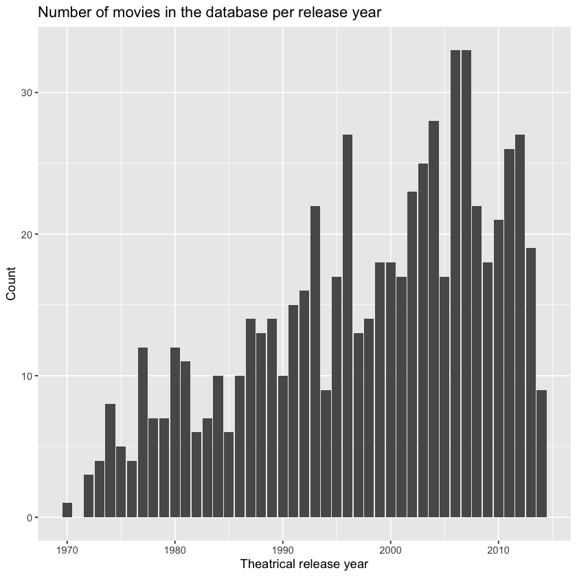

```r
ggplot(data = movies, aes(x = thtr_rel_year)) +
  geom_bar() +
  ggtitle("Number of movies in the database per release year") +
  labs(x = "Theatrical release year", y = "Count")
```

## 4. Now it's your turn

**Task A**

1. Plot the relationship between: `imdb_rating`, `imdb_num_votes` and `audience_score`.
2. Change the coloring of the scatterplot. You can either have a look [here](https://ggplot2.tidyverse.org/reference/scale_gradient.html) or simply change the two colors in the gradients, and have a look for example [here](http://sape.inf.usi.ch/quick-reference/ggplot2/colour).
3. Compute the regression for such relationship.

**Task B**

1. Plot the relationship between `best_actor_win`, `best_actress_win` and `audience_score`.
2. Compute the ANOVA for such relationship.

**Task C**

1. Plot the number of movies in each `mpaa_rating` category.

## Submit your assignment

Save and email your `wpa_1_LastFirst.R` script to me at laura.fontanesi@unibas.ch by the end of Friday.